# Visceral Leishmaniasis Spatial Risk Modeling Pipeline

Eneza Data Science Cohort 3 — Stefanie Rwamba Njagi

2026-04-30

## Executive Summary

This document outlines the complete data science pipeline for evaluating the spatial transmission dynamics of Visceral Leishmaniasis (VL) in Kenya. Developed as part of the icipe Eneza Data Science Training Programme in collaboration with the Centre for Epidemiological Modelling and Analysis (CEMA), the workflow encompasses:

Spatial covariate preparation (environmental, socioeconomic, infrastructural)

Epidemiological data extraction and pseudo-absence generation

Exploratory data analysis including spatial autocorrelation testing

Machine learning model evaluation using standardized scaling and multi-ratio evaluation

Four algorithms were evaluated — GLM, Random Forest, XGBoost, and Decision Tree — under a unified preprocessing protocol to ensure strict methodological comparability.

## Chapter 1: Spatial Covariate Preparation

Before modeling, raw socioeconomic and infrastructural data must be converted into continuous spatial rasters that mathematically align with the environmental covariates. All rasters are aligned to a common template grid derived from the 2025 Greenness layer.

```r
library(terra)
library(dplyr)
library(tidygeocoder)
library(sf)

# Load master template to enforce identical resolutions and extents
template_raster    <- rast(file.path(env_dir, "Greenness_2025.tif"))
blank_grid         <- template_raster
values(blank_grid) <- NA
```

### 1.1 Wealth Index Rasterization

Converts localized relative wealth index CSV data into a continuous grid using spatial interpolation. The focal smoothing step fills spatial gaps to ensure complete national coverage.

```r
wealth_data          <- read.csv(file.path(HOME, "ken_relative_wealth_index.csv"))
wealth_pts           <- vect(wealth_data, geom = c("longitude", "latitude"),
                               crs = crs(template_raster))
wealth_raster        <- rasterize(wealth_pts, template_raster, field = "rwi", fun = "mean")
wealth_raster_filled <- focal(wealth_raster, w = 3, fun = mean,
                               na.policy = "only", na.rm = TRUE)
writeRaster(wealth_raster_filled, file.path(output_dir, "Wealth_Index.tif"),
            overwrite = TRUE)
```

### 1.2 Euclidean Distance to Water Bodies

Calculates pixel-wise distance to the nearest rivers and lakes. Water proximity is ecologically relevant as Phlebotomus sandflies preferentially breed in humid microhabitats near water sources.

```r
rivers_vect <- project(
  vect(file.path(HOME, "hydro_folder", "HydroRIVERS_v10_af.gdb")),
  crs(template_raster)
)
lakes_vect <- project(
  vect(file.path(HOME, "hydro_folder", "lakes", "HydroLAKES_points_v10_shp",
                  "HydroLAKES_points_v10.shp")),
  crs(template_raster)
)

water_raster_rivers <- rasterize(rivers_vect, blank_grid, background = NA, field = 1)
water_raster_lakes  <- rasterize(lakes_vect,  blank_grid, background = NA, field = 1)
water_combined      <- merge(water_raster_rivers, water_raster_lakes)

final_water_km        <- mask((distance(water_combined) / 1000), template_raster)
names(final_water_km) <- "Water_Distance_km"
writeRaster(final_water_km, file.path(output_dir, "Water_Distance.tif"), overwrite = TRUE)
```

### 1.3 Euclidean Distance to Healthcare (Surveillance Bias Correction)

Geocodes the 40 diagnostic facilities in the dataset to establish the spatial limit of surveillance detection. This covariate serves as a proxy for case ascertainment bias — areas further from facilities are systematically underrepresented in the case data.

```r
epidata          <- read.csv(file.path(HOME, "Kenya EpiData Complete 2.csv"))
unique_hospitals <- epidata %>%
  select(Facility_Name = Health_facility) %>%
  distinct() %>%
  filter(!is.na(Facility_Name) & Facility_Name != "") %>%
  mutate(search_name = paste0(Facility_Name, ", Kenya"))

valid_hospitals <- unique_hospitals %>%
  geocode(address = search_name, method = "osm",
          lat = latitude, long = longitude) %>%
  filter(!is.na(latitude) & !is.na(longitude))

hosp_pts            <- vect(valid_hospitals, geom = c("longitude", "latitude"),
                             crs = crs(template_raster))
hosp_raster         <- rasterize(hosp_pts, blank_grid, background = NA, field = 1)
final_healthcare_km <- mask((distance(hosp_raster) / 1000), template_raster)
names(final_healthcare_km) <- "Healthcare_Access_km"
writeRaster(final_healthcare_km, file.path(output_dir, "Healthcare_Access.tif"),
            overwrite = TRUE)
```

### 1.4 Population Density Alignment

```r
pop_raw   <- rast(file.path(HOME, "ken_ppp_2020_constrained.tif"))
final_pop <- mask(
  resample(project(pop_raw, crs(template_raster)), template_raster,
           method = "bilinear"),
  template_raster
)
names(final_pop) <- "Population_Density"
writeRaster(final_pop, file.path(output_dir, "Population_Density.tif"),
            overwrite = TRUE)
```

## Chapter 2: Covariate Extraction

With the rasters prepared, we extract the underlying ecological and socioeconomic values for all true case coordinates and generated pseudo-absences. The final dataset combines eight predictors spanning environmental, socioeconomic, and infrastructural dimensions.

```r
prediction_stack <- c(
  rast(file.path(env_dir,    "Greenness_2025.tif")),
  rast(file.path(env_dir,    "Rainfall_2025.tif")),
  rast(file.path(env_dir,    "Temperature_2025.tif")),
  rast(file.path(env_dir,    "RH_2025.tif")),
  rast(file.path(output_dir, "Wealth_Index.tif")),
  rast(file.path(output_dir, "Water_Distance.tif")),
  rast(file.path(output_dir, "Healthcare_Access.tif")),
  rast(file.path(output_dir, "Population_Density.tif"))
)
names(prediction_stack) <- c("Greenness", "Rainfall", "Temperature", "RH",
                               "Wealth_Index", "Water_Distance_km",
                               "Healthcare_Access_km", "Population_Density")

pts_df           <- read.csv(file.path(output_dir, "VL_Model_Ready_Data_Ratio_1_1.csv"))
extracted_values <- extract(prediction_stack,
                             vect(pts_df, geom = c("Longitude", "Latitude"),
                                  crs = crs(prediction_stack)))
saveRDS(na.omit(cbind(pts_df, extracted_values[, -1])),
        file.path(output_dir, "VL_Model_Ready_Data_Ratio_1_1.rds"))
```

## Chapter 3: Exploratory Data Analysis

Spatial analysis of the underlying data distribution to test for spatial autocorrelation and covariate variance. All analyses are performed on the 1:1 presence-absence dataset.

```r
library(ggplot2)
library(tidyr)
library(corrplot)
library(spdep)

# Load the finalized dataset — CSV read avoids duplicate column issues from cbind/RDS
model_data <- read.csv(file.path(output_dir, "VL_Model_Ready_Data_Ratio_1_1.csv"))
names(model_data) <- make.names(names(model_data), unique = TRUE)
true_cases <- model_data %>% filter(Status == 1)

env_cols       <- c("Greenness", "Rainfall", "Temperature", "RH")
socio_cols     <- c("Healthcare_Access_km", "Water_Distance_km",
                    "Population_Density", "Wealth_Index")
all_predictors <- c(env_cols, socio_cols)
```

### 3.1 Temporal Trends

Annual and monthly case counts reveal the epidemiological trajectory of VL in Kenya over the study period (2020–2025).

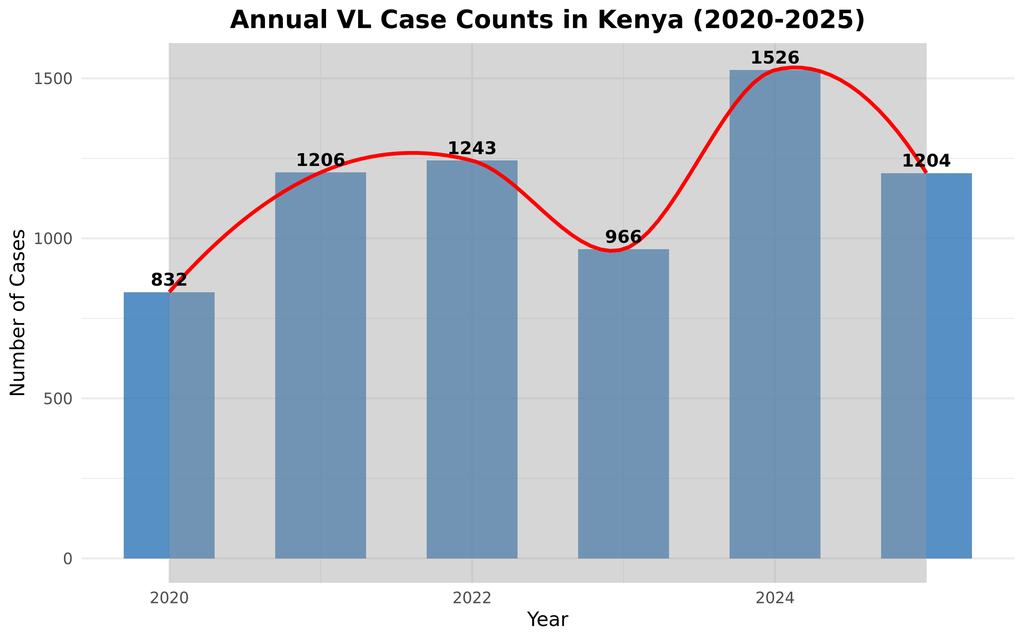

```r
knitr::include_graphics(file.path(output_dir, "EDA_01_VL_Annual_Case_Trend_2020_2025.png"))
```

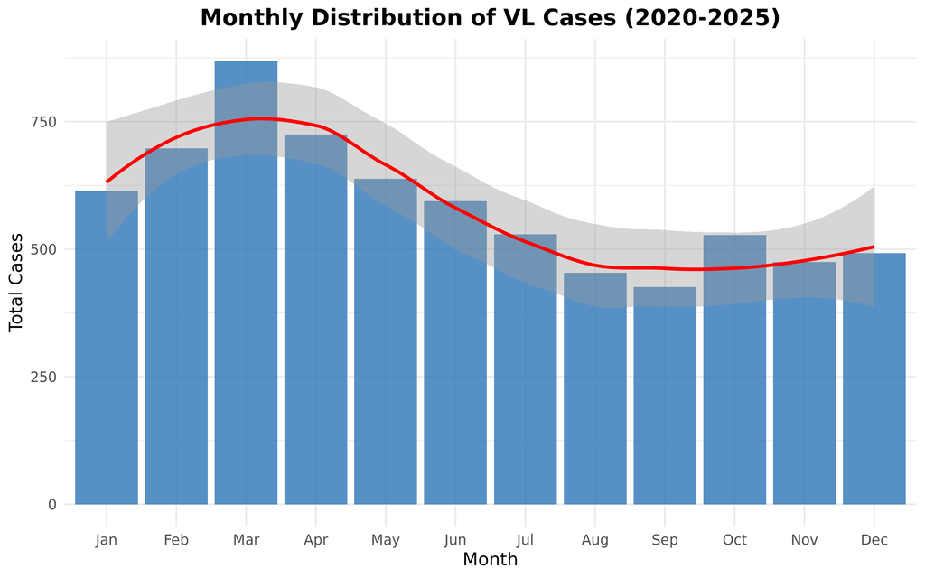

```r
knitr::include_graphics(file.path(output_dir, "EDA_02_Monthly_Seasonality.png"))
```

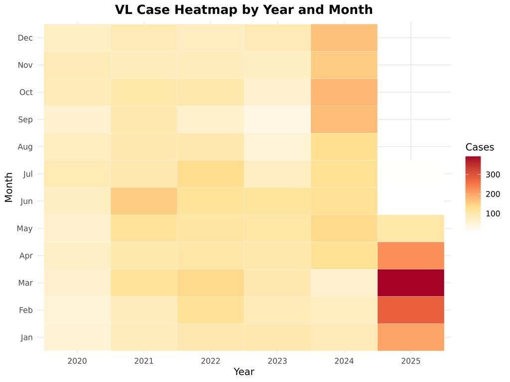

```r
knitr::include_graphics(file.path(output_dir, "EDA_03_Temporal_Heatmap.png"))
```

### 3.2 Spatial Distribution and Profiling

```r
kenya_1  <- st_read(
  file.path(HOME, "shapefiles/Shapesfiles/gadm41_KEN_1.shp"),
  quiet = TRUE
)
model_sf     <- st_as_sf(true_cases, coords = c("Longitude", "Latitude"), crs = 4326)
cases_county <- st_join(model_sf, kenya_1["NAME_1"], join = st_within)
county_counts <- cases_county %>%
  st_drop_geometry() %>%
  group_by(NAME_1) %>%
  summarise(total_cases = n(), .groups = "drop")
kenya_cases <- kenya_1 %>%
  left_join(county_counts, by = "NAME_1") %>%
  mutate(total_cases = tidyr::replace_na(total_cases, 0))
```

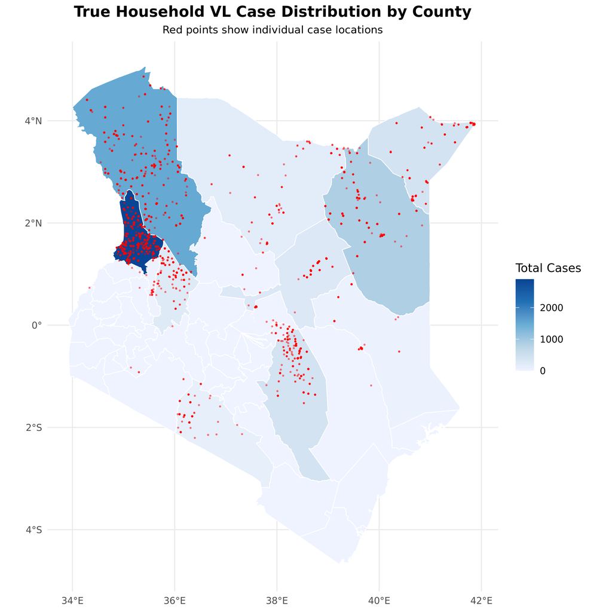

```r
knitr::include_graphics(file.path(output_dir, "EDA_04_County_Choropleth.png"))
```

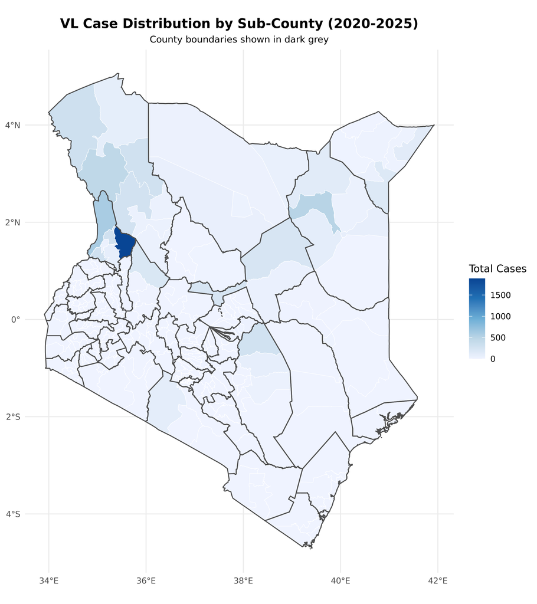

```r
knitr::include_graphics(file.path(output_dir, "EDA_04_VL_Subcounty_Choropleth.png"))
```

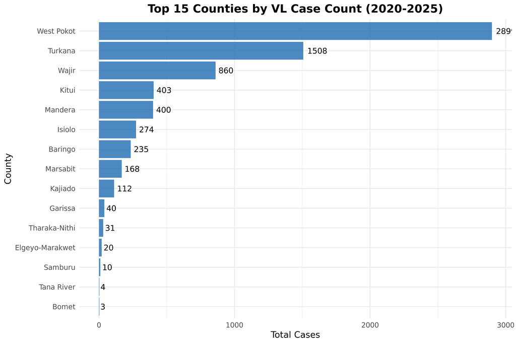

```r
knitr::include_graphics(file.path(output_dir, "EDA_05_VL_Top15_Counties_Barplot.png"))
```

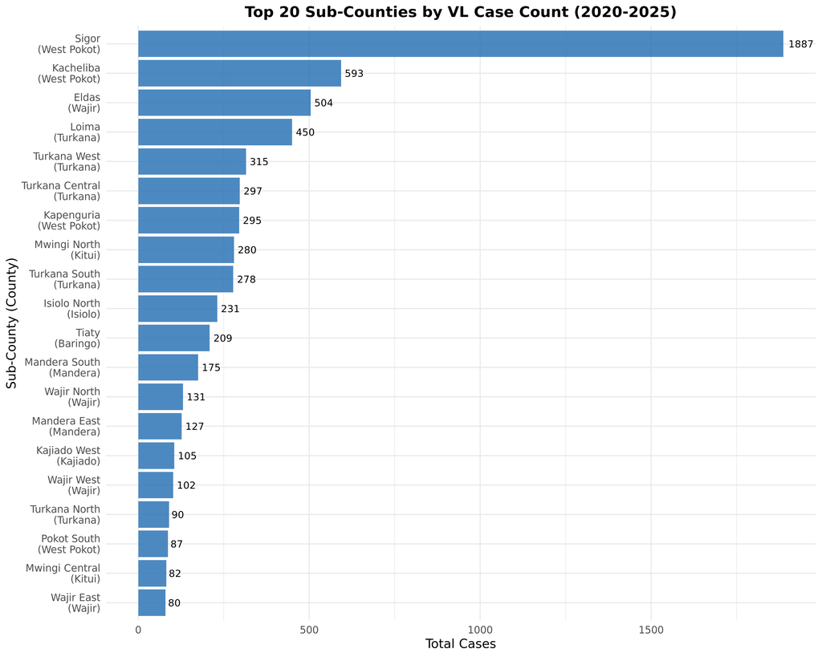

```r
knitr::include_graphics(file.path(output_dir, "EDA_05_VL_Top20_Subcounties.png"))
```

### 3.3 Spatial Autocorrelation — Getis-Ord Gi* Hotspot Analysis

```r
nb <- poly2nb(kenya_cases, queen = TRUE)
lw <- nb2listw(nb, style = "W", zero.policy = TRUE)
moran.test(kenya_cases$total_cases, lw, zero.policy = TRUE)
```

```
##
##  Moran I test under randomisation
##
## data:  kenya_cases$total_cases
## weights: lw
##
## Moran I statistic standard deviate = 3.7221, p-value = 9.878e-05
## alternative hypothesis: greater
## sample estimates:
## Moran I statistic       Expectation          Variance
##       0.217037888      -0.021739130       0.004115353
```

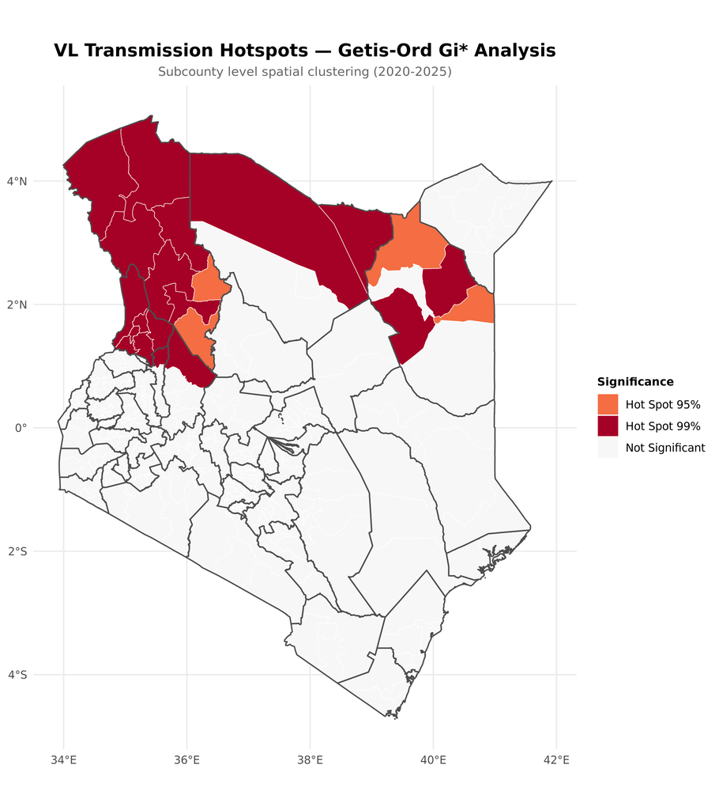

```r
knitr::include_graphics(file.path(output_dir, "EDA_12_Getis_Ord_Gi_Hotspots.png"))
```

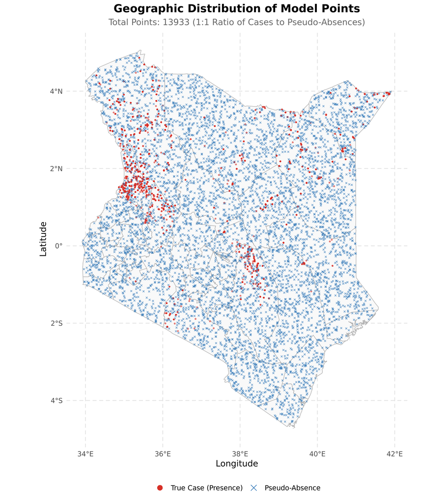

```r
knitr::include_graphics(file.path(output_dir, "EDA_13_Cases_vs_Absences_Map.png"))
```

### 3.4 Environmental Covariate Distributions

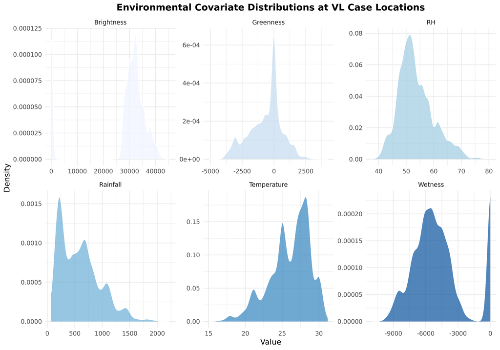

```r
knitr::include_graphics(file.path(output_dir, "EDA_07_Environmental_Covariate_Distributions.png"))
```

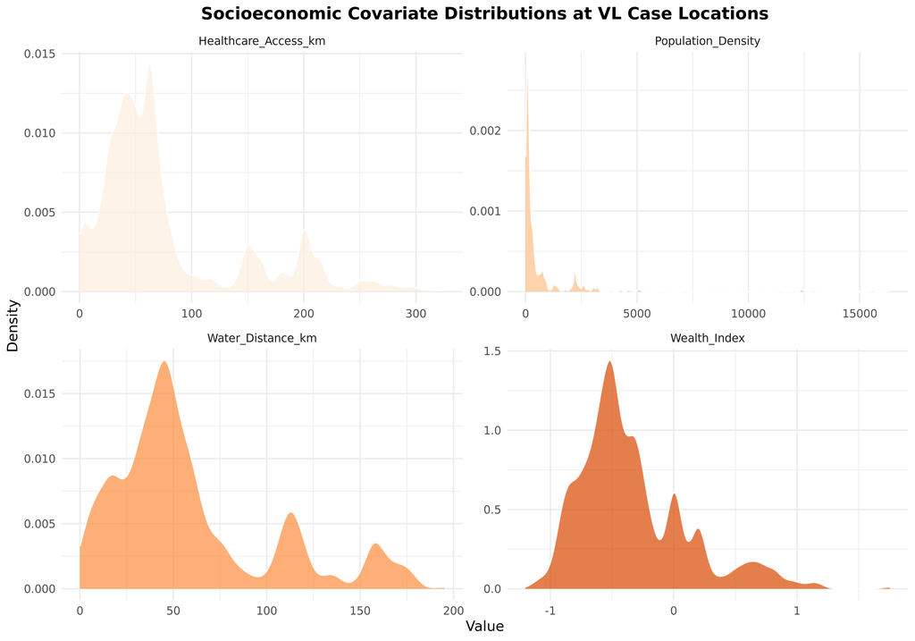

```r
knitr::include_graphics(file.path(output_dir, "EDA_07_Socio_Distributions.png"))
```

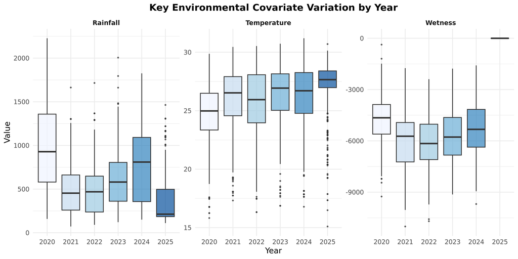

```r
knitr::include_graphics(file.path(output_dir, "EDA_09_Environmental_Variation_By_Year.png"))
```

### 3.5 Socioeconomic Profile

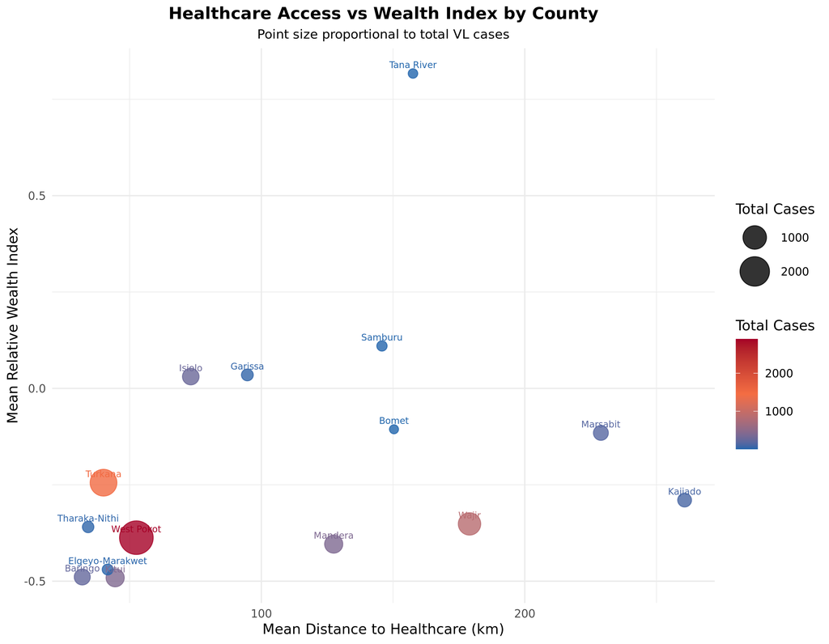

```r
knitr::include_graphics(file.path(output_dir, "EDA_10_Socioeconomic_Profile.png"))
```

### 3.6 Predictor Correlation & Multicollinearity

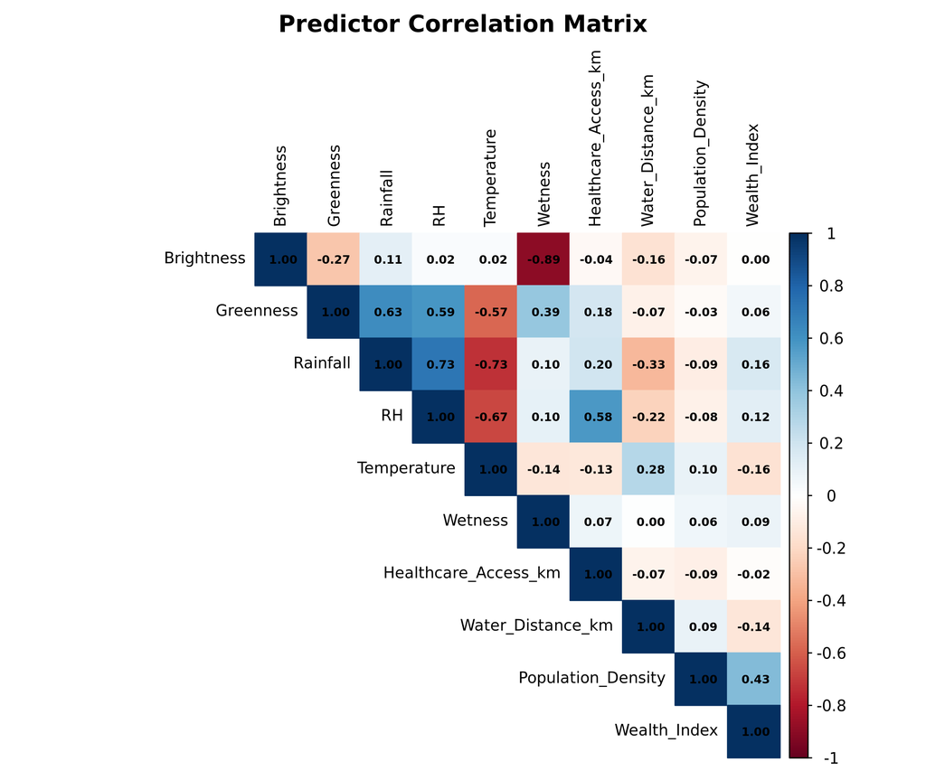

```r
knitr::include_graphics(file.path(output_dir, "EDA_09_Predictor_Correlation_Matrix.png"))
```

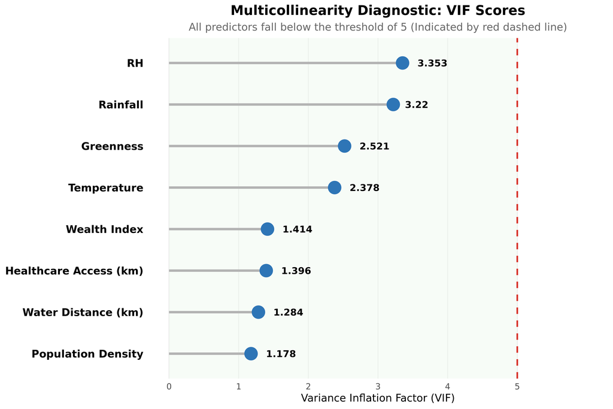

```r
knitr::include_graphics(file.path(output_dir, "EDA_VIF_Lollipop_Plot.png"))
```

## Chapter 4: Machine Learning Evaluation

Evaluating parametric vs. non-parametric learners. To ensure strict methodological comparability, an explicit formula is used and universal scaling is applied to both training and test sets across all four algorithms.

### 4.0 Multi-Ratio Performance Evaluation

Before selecting the final model architecture, algorithms were evaluated across multiple presence-to-pseudo-absence ratios (1:1, 1:2, 1:5) to assess sensitivity to class imbalance.

```r
tryCatch({
  multi_ratio_results <- read.csv(file.path(output_dir, "MASTER_All_Models_Performance.csv"))
  knitr::kable(multi_ratio_results, caption = "Table 1. Algorithm performance across multiple pseudo-absence generation ratios.")
}, error = function(e) {
  message("Multi-ratio performance table not found.")
})
```

[output not shown]

```r
library(caret)
library(pROC)
library(randomForest)
library(xgboost)
library(rpart)
library(rpart.plot)
library(broom)
library(patchwork)

model_data$Status_factor <- factor(
  ifelse(model_data$Status == "1" | model_data$Status == "Presence", "1", "0"),
  levels = c("0", "1")
)
model_data$Status_num <- ifelse(model_data$Status_factor == "1", 1, 0)

# Explicit formula
explicit_formula <- as.formula(
  paste("Status_factor ~", paste(all_predictors, collapse = " + "))
)

# 80/20 stratified split
set.seed(123)
trainIndex  <- createDataPartition(model_data$Status_factor, p = 0.8, list = FALSE)
train_data  <- model_data[trainIndex, ]
test_data   <- model_data[-trainIndex, ]

# Universal scaling — fit on training set only
preProc      <- preProcess(train_data[, all_predictors], method = c("center", "scale"))
train_scaled <- predict(preProc, train_data)
test_scaled  <- predict(preProc, test_data)

dtrain_scaled <- xgb.DMatrix(
  data  = as.matrix(train_scaled[, all_predictors]),
  label = train_scaled$Status_num
)
dtest_scaled <- xgb.DMatrix(
  data  = as.matrix(test_scaled[, all_predictors]),
  label = test_scaled$Status_num
)
```

### 4.1 Algorithm Training (Scaled Inputs)

```r
# 1. Generalized Linear Model
glm_mod  <- glm(explicit_formula, data = train_scaled,
                 family = binomial(link = "logit"))
glm_prob <- predict(glm_mod, newdata = test_scaled, type = "response")

# 2. Random Forest (500 trees)
set.seed(123)
rf_mod  <- randomForest(explicit_formula, data = train_scaled,
                         ntree = 500, importance = TRUE)
rf_prob <- predict(rf_mod, newdata = test_scaled, type = "prob")[, "1"]

# 3. XGBoost with 5-Fold Cross Validation
set.seed(123)
xgb_params <- list(objective = "binary:logistic", eval_metric = "auc",
                    max_depth = 4, eta = 0.1)
cv_res <- xgb.cv(params = xgb_params, data = dtrain_scaled, nrounds = 300,
                  nfold = 5, early_stopping_rounds = 20,
                  verbose = 0, stratified = TRUE)
# Safety net: fallback to 150 trees if best_iteration is NULL
best_trees <- cv_res$best_iteration
if (is.null(best_trees) || length(best_trees) == 0) best_trees <- 150
xgb_mod  <- xgb.train(params = xgb_params, data = dtrain_scaled,
                        nrounds = best_trees, verbose = 0)
xgb_prob <- predict(xgb_mod, dtest_scaled)

# 4. Decision Tree (max depth = 4, cp = 0.01)
set.seed(123)
tree_mod  <- rpart(explicit_formula, data = train_scaled, method = "class",
                    control = rpart.control(cp = 0.01, maxdepth = 4))
tree_prob <- predict(tree_mod, newdata = test_scaled, type = "prob")[, "1"]
```

### 4.2 Performance Metrics (Holdout Evaluation)

```r
models       <- list("GLM"           = glm_prob,
                      "Random Forest" = rf_prob,
                      "XGBoost"       = xgb_prob,
                      "Decision Tree" = tree_prob)
results_list <- list()

for (model_name in names(models)) {
  prob     <- models[[model_name]]
  roc_obj  <- roc(test_scaled$Status_factor, prob, quiet = TRUE)
  conf_mat <- confusionMatrix(
    factor(ifelse(prob > 0.5, "1", "0"), levels = c("0", "1")),
    test_scaled$Status_factor, positive = "1"
  )
  results_list[[model_name]] <- data.frame(
    Model = model_name,
    AUC   = round(as.numeric(auc(roc_obj)), 3),
    TSS   = round(as.numeric(conf_mat$byClass["Sensitivity"]) +
                  as.numeric(conf_mat$byClass["Specificity"]) - 1, 3)
  )
}
knitr::kable(
  bind_rows(results_list) %>% arrange(desc(AUC)),
  caption = "Table 2. Baseline model performance on held-out test set (AUC and TSS)."
)
```

Table 2. Baseline model performance on held-out test set (AUC and TSS).

[output not shown]

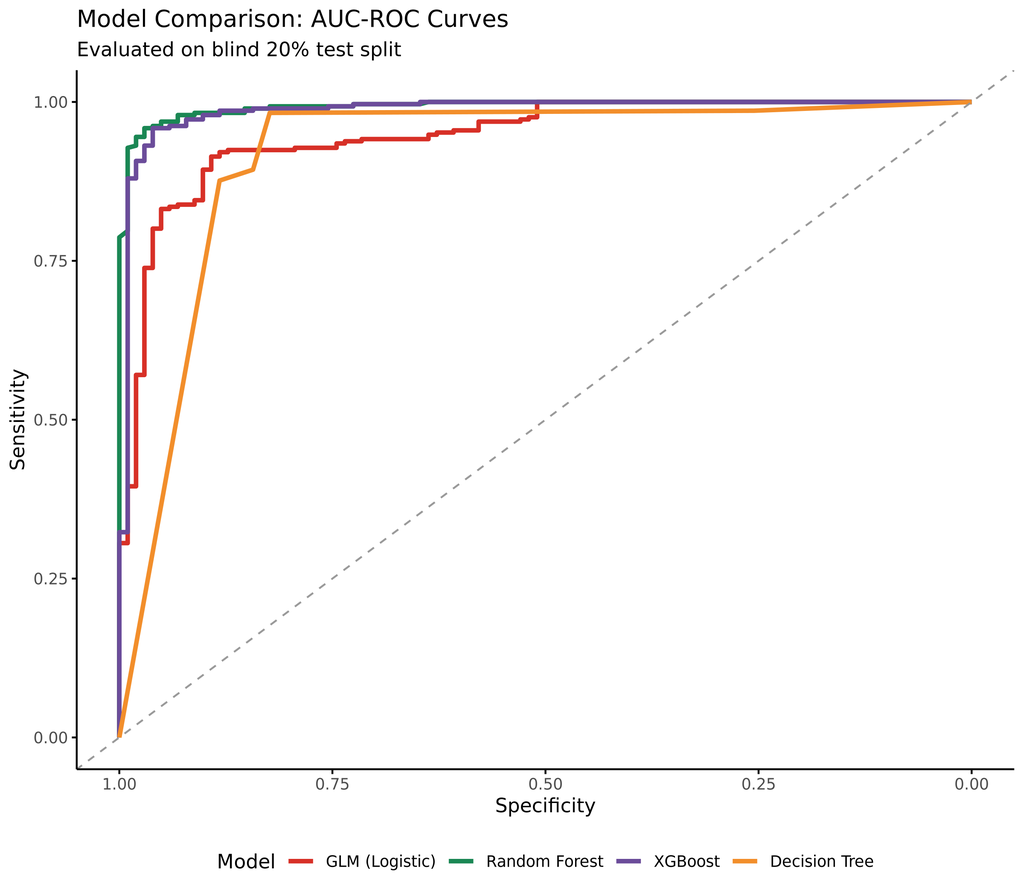

```r
knitr::include_graphics(file.path(output_dir, "Synthesis_ROC_Comparison.png"))
```

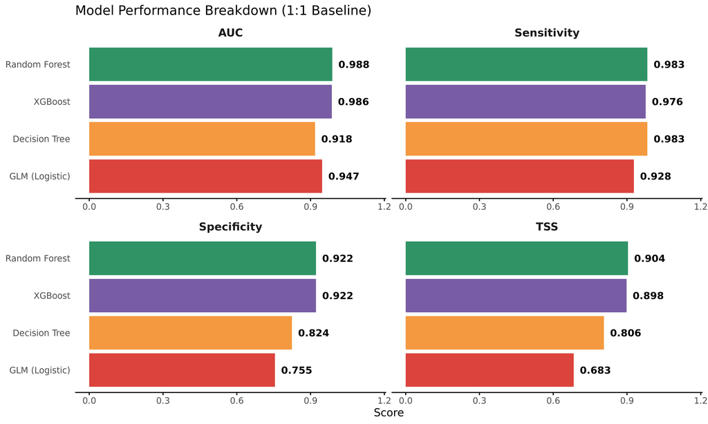

```r
knitr::include_graphics(file.path(output_dir, "Synthesis_Metrics_Comparison.png"))
```

### 4.3 Feature Interpretability

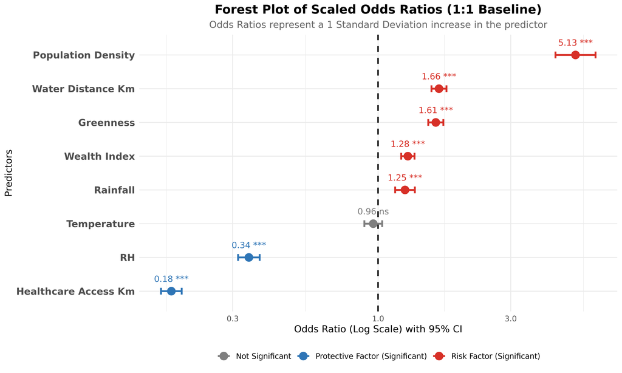

```r
knitr::include_graphics(file.path(output_dir, "Model_01_GLM_Forest_Plot.png"))
```

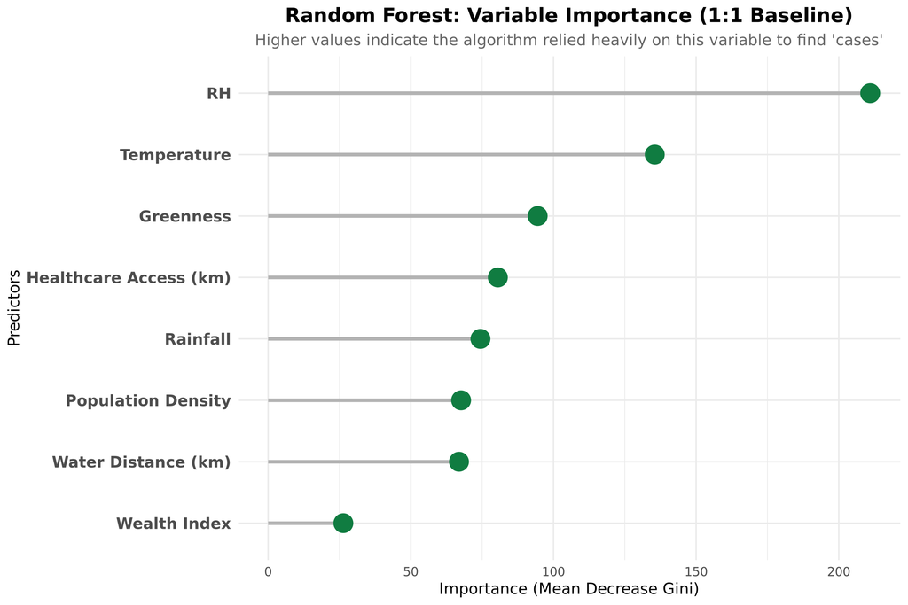

```r
knitr::include_graphics(file.path(output_dir, "Model_02_RF_VarImportance.png"))
```

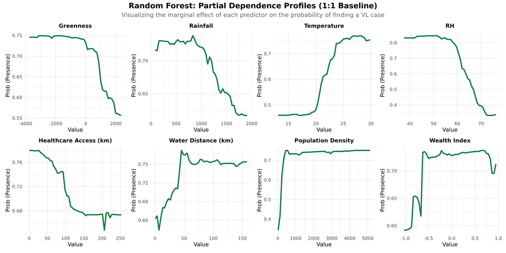

```r
knitr::include_graphics(file.path(output_dir, "Model_02_RF_PDP_Grid.png"))
```

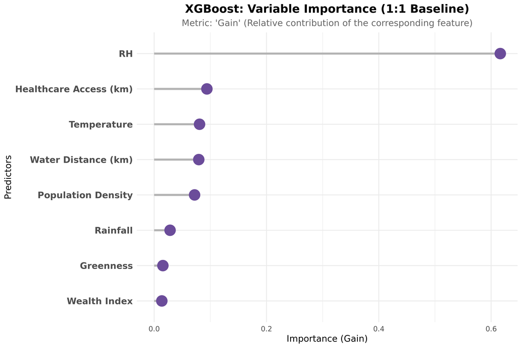

```r
knitr::include_graphics(file.path(output_dir, "Model_03_XGB_VarImportance.png"))
```

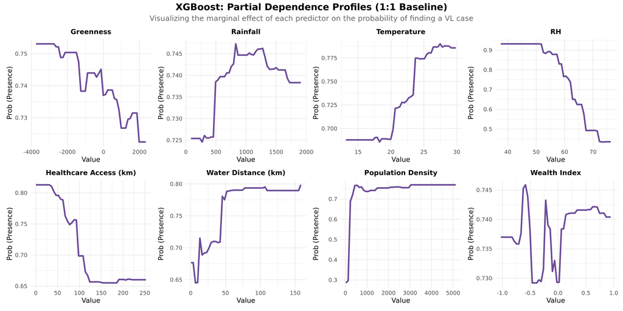

```r
knitr::include_graphics(file.path(output_dir, "Model_03_XGB_PDP_Grid.png"))
```

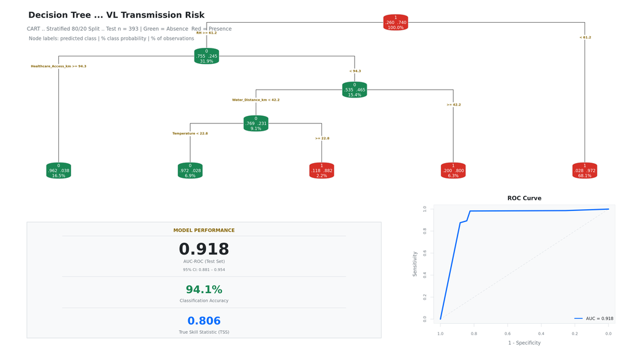

```r
knitr::include_graphics(file.path(output_dir, "Model_04_Tree_Publication.png"))
```

### 4.4 SHAP Analysis (XGBoost)

SHAP (SHapley Additive exPlanations) values provide a unified framework for interpreting individual predictions from the XGBoost model, decomposing each prediction into per-feature contributions.

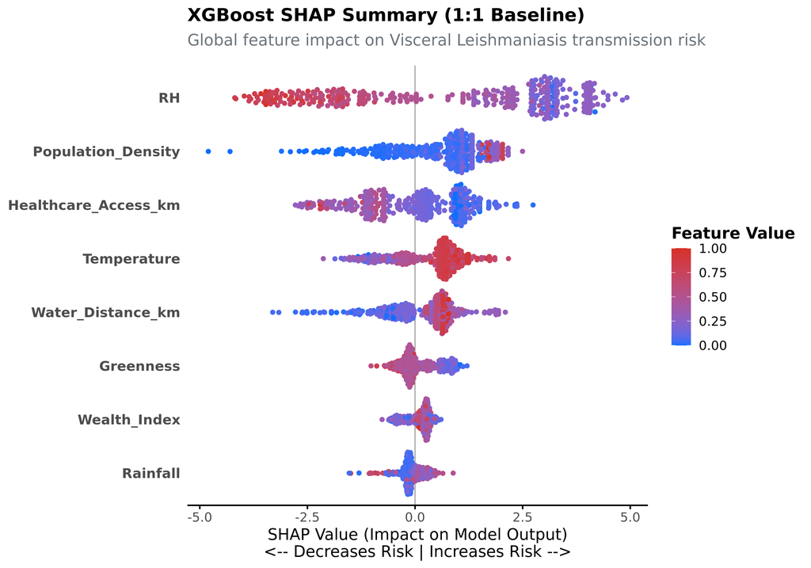

```r
knitr::include_graphics(file.path(output_dir, "Publication_SHAP_Summary.png"))
```

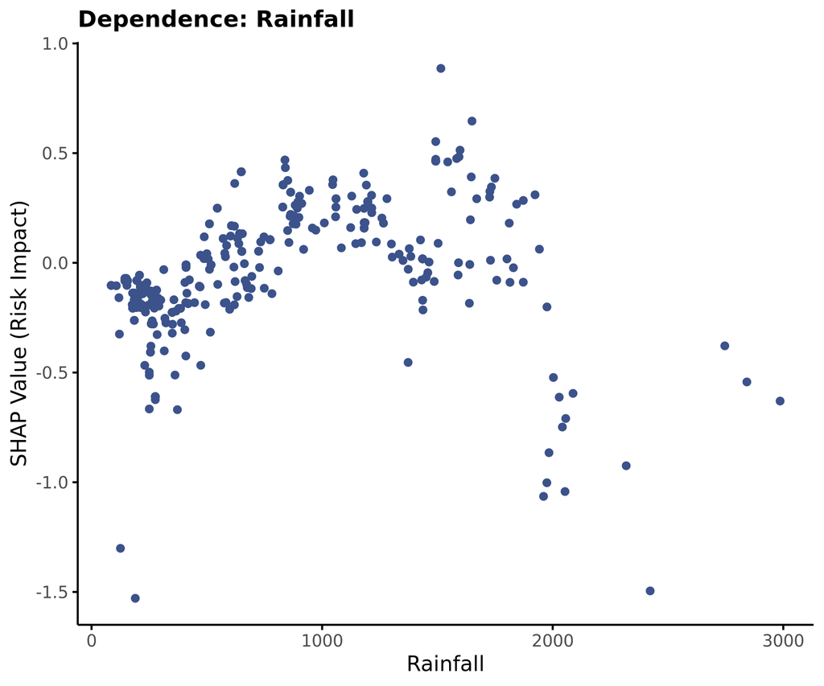

```r
knitr::include_graphics(file.path(output_dir, "Publication_SHAP_Dep_Rainfall.png"))
```

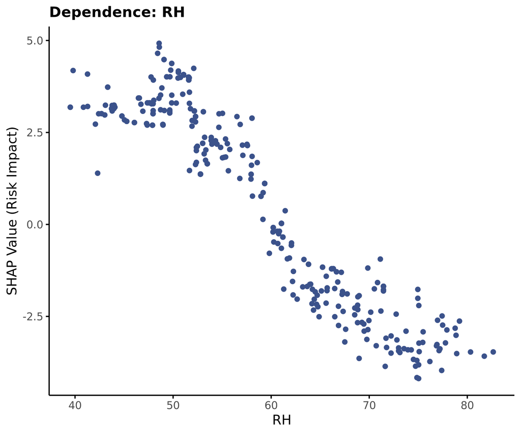

```r
knitr::include_graphics(file.path(output_dir, "Publication_SHAP_Dep_RH.png"))
```

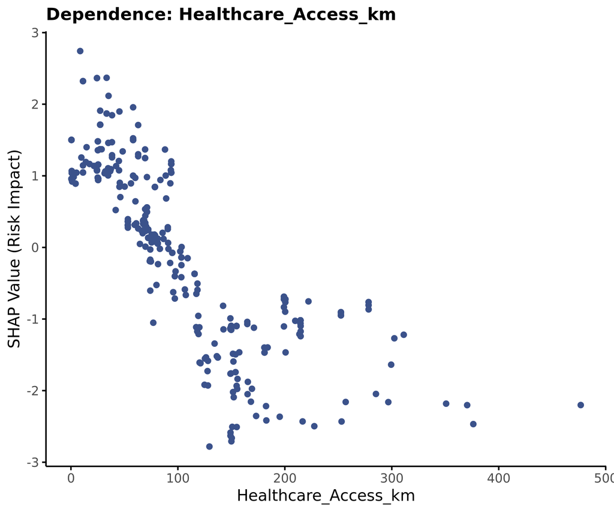

```r
knitr::include_graphics(file.path(output_dir, "Publication_SHAP_Dep_Healthcare_Access_km.png"))
```

## Chapter 5: Final Risk Map Projection

The final step applies the fully optimized and scaled XGBoost model back onto the continuous national spatial grid. The 2025 risk map was generated via an optimized standalone R script (Test_Risk_Map.R) executed on the HPC server, utilizing universal data scaling, native XGBoost NA-handling for robust continuous predictions in data-sparse rural regions, and dynamic shapefile border masking.

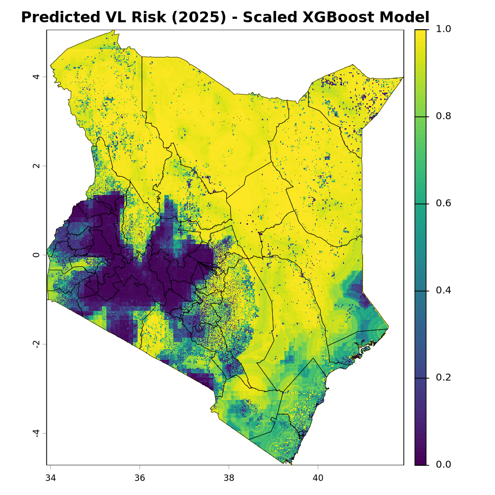

```r
knitr::include_graphics(file.path(output_dir, "VL_Risk_Map_2025_Publication.png"))
```

### 5.1 Risk Category Summary

```r
library(terra)
library(dplyr)

# Load the pre-calculated risk map
risk_map_final <- rast(file.path(output_dir, "VL_Risk_Map_2025_Final.tif"))
risk_df        <- as.data.frame(risk_map_final, na.rm = TRUE)
colnames(risk_df) <- "VL_Risk_2025"

risk_df$Risk_Category <- cut(
  risk_df$VL_Risk_2025,
  breaks         = c(0, 0.2, 0.4, 0.6, 0.8, 1.0),
  labels         = c("Very Low (0-20%)", "Low (20-40%)", "Moderate (40-60%)",
                     "High (60-80%)", "Very High (80-100%)"),
  include.lowest = TRUE
)

risk_summary <- risk_df %>%
  group_by(Risk_Category) %>%
  summarise(
    Pixel_Count  = n(),
    Percent_Area = round(n() / nrow(risk_df) * 100, 1),
    .groups      = "drop"
  )

knitr::kable(
  risk_summary,
  caption    = "Table 3. Distribution of predicted VL risk categories across Kenya (2025).",
  col.names  = c("Risk Category", "Pixel Count", "% of Land Area")
)
```

Table 3. Distribution of predicted VL risk categories across Kenya (2025).

| Risk Category | Pixel Count | % of Land Area |
| --- | --- | --- |
| Very Low (0-20%) | 88069 | 14.8 |
| Low (20-40%) | 23540 | 4.0 |
| Moderate (40-60%) | 23535 | 4.0 |
| High (60-80%) | 62426 | 10.5 |
| Very High (80-100%) | 395649 | 66.7 |